# PSL (F20) Coding Assignment 3

Vijayakumar Sitha Mohan (VS24), Waitong Matthew Leung (wmleung2)

12-Oct-2020

## Introduction

Write my own functions to use LOO-CV and GCV to select the optimal span for loess.

- Test my code on data set Coding3 Data.csv, which we downloaded from Piazza.
- Report my CV and GCV for 15 span values: 0.20; 0.25;… ; 0.90.
- Report the optimal value(s) for span based on CV and GCV.
- Plot the fitted curve(s) using the optimal value(s) for span.

## Prepare my function

Write my own function to use LOO-CV and GCV to select the optimal span for loess.

```r
lo.lev <- function(x1, sp){
  # x1: feature vector of length n
  # sp: a value for "span"

  n = length(x1);
  lev = rep(0, n)

  ##############################################
  # YOUR CODE: Compute the diagonal entries of the
  #            smoother matrix S and
  #            store it in a vector "lev"
  # Tip: check how we compute the smoother matrix
  #      for smoothing spline models

  for(i in 1:n){
    y = rep(0, n); y[i]=1;
    yi = loess(y ~ x1, span = sp)$fitted;
    lev[i]= yi[i];
  }

  ##############################################


  return(lev)
}

onestep_CV <- function(x1, y1, sp){

  ##############################################
  #  YOUR CODE:
  #  1) Fit a loess model y1 ~ x1 with span = sp, and extract
  #     the corresponding residual vector
  #  2) Call lo.lev to obtain the diagonal entries of S
  #  3) Compute LOO-CV and GCV using formula from lecture notes
  #    [lec_W5_NonlinearRegression.pdf] page 33.

  n = length(x1)
  err = y1 - loess(y1 ~ x1, span = sp)$fitted
  sdiag = lo.lev(x1, sp)

  cv = sum((err/(1-sdiag))^2)/n
  gcv = sum((err/(1-sum(sdiag)/n))^2)/n

  ##############################################

  return(list(cv = cv, gcv = gcv))
}

myCV <- function(x1, y1, span){
  # x1: feature vector of length n
  # y1: response vector of length n
  # span: a sequence of values for "span"

  m = length(span)
  cv = rep(0, m)
  gcv = rep(0, m)

  for(i in 1:m){
    tmp = onestep_CV(x1, y1, span[i])
    cv[i] = tmp$cv
    gcv[i] = tmp$gcv
  }
  return(list(cv = cv, gcv = gcv))
}
```

## Test my function

Test my function with data “Coding3_Data.csv.”

```r
mydata = read.csv(file = "Coding3_Data.csv")
dim(mydata)
```

```
## [1] 30  2
```

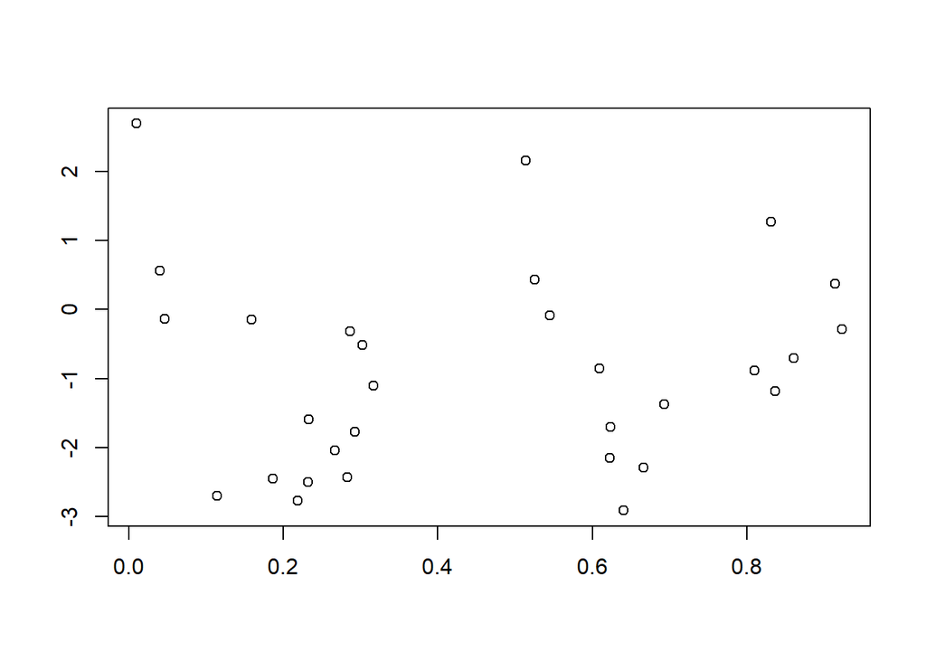

```r
plot(mydata$x, mydata$y, xlab="", ylab="")
```

Create a grid of values for span: 15 values that are equally spaced between 0.20 and 0.90. Call your function myCV to compute the corresponding LOO-CV and GCV.

```r
span1 = seq(from = 0.2, by = 0.05, length = 15 )
cv.out = myCV(mydata$x, mydata$y, span1)
```

## Results : Print out my results

Print my results on LOO-CV and GCV. Both achieve their minimal at 0.5.

```r
myout = data.frame(CV = cv.out$cv,
                   GCV = cv.out$gcv,
                   span = span1)
myout
```

```
##        CV   GCV span
## 1  12.416 2.110 0.20
## 2   2.241 1.489 0.25
## 3   1.503 1.190 0.30
## 4   1.259 1.174 0.35
## 5   1.190 1.103 0.40
## 6   1.157 1.063 0.45
## 7   1.124 1.040 0.50
## 8   1.180 1.119 0.55
## 9   1.179 1.119 0.60
## 10  1.251 1.181 0.65
## 11  1.554 1.519 0.70
## 12  1.636 1.627 0.75
## 13  1.765 1.745 0.80
## 14  1.976 1.926 0.85
## 15  2.035 1.980 0.90
```

```r
myout$span[myout$GCV == min(myout$GCV)]
```

```
## [1] 0.5
```

```r
myout$span[myout$CV == min(myout$CV)]
```

```
## [1] 0.5
```

## Plot the fitted curve

Plot the data (red circles), the true curve (gray) and the fitted curve (blue dashed line) using the optimal span.

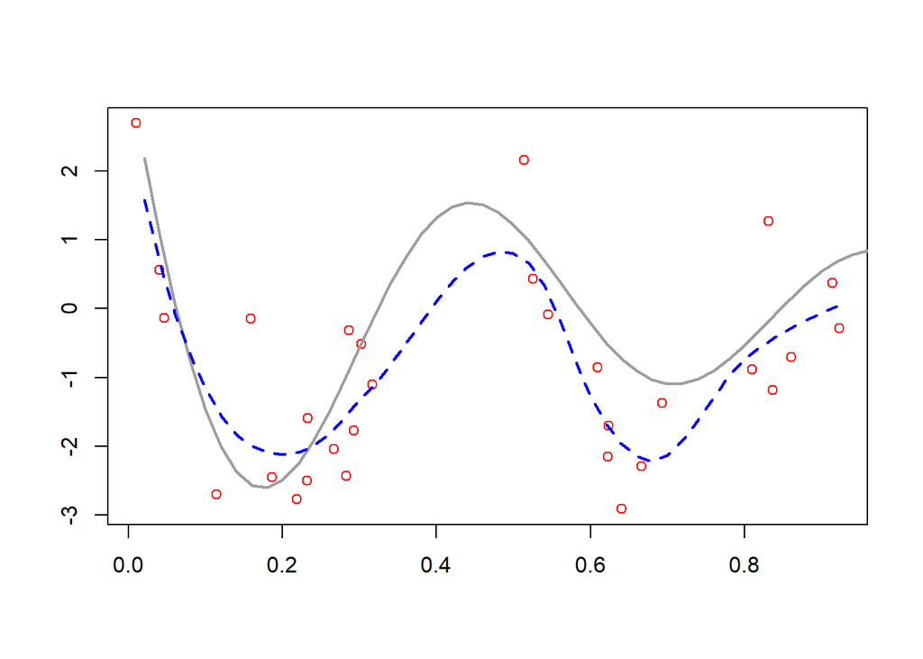

```r
spangcv.min = 0.5
plot(mydata$x, mydata$y, xlab="", ylab="", col="red");
fx = 1:50/50;
fy = sin(12*(fx+0.2))/(fx+0.2)
lines(fx, fy, col=8, lwd=2, color = "gray");

f = loess(y ~ x, mydata, span = spangcv.min)
lines(fx, predict(f, newdata = data.frame(x = fx), surface = "direct"), lty=2, lwd=2, col="blue")
```

## Contribution

Vijayakumar Mohan contributes to verification of implementation and enhancement of visualization.

Matthew Leung contributes to implementation of LOO-CV/GCV and overall presentation of the report